# Report

Avishek Saha, Jonah Edmundson, Madison Greenough

2023-04-10

# Introduction

The Canadian Lynx, known scientifically as the *Lynx canadensis Kerr*, are a marvelous species found within British Columbia. For this report, a spatial analysis of this species will be conducted. They will be referred to as their shorter name, lynx, for the duration of this report. Given that the lynx are a part of the feline family, we hypothesize that they will habitate in forested areas, in small groups, with minimal movement. In other words, we expect that they will reside in an area long term without significant travelling or relocating. We also predict that they will reside in colder locations, so their presence may not be found in the warmer areas of BC, such as the southern interior. We expect that we cannot assume homogeneity for this specific species, as we expect the lynx to be found in clusters rather than evenly distributed across BC. We expect that the lynx would be found at higher elevations due to their thicker coats and natural behaviours.

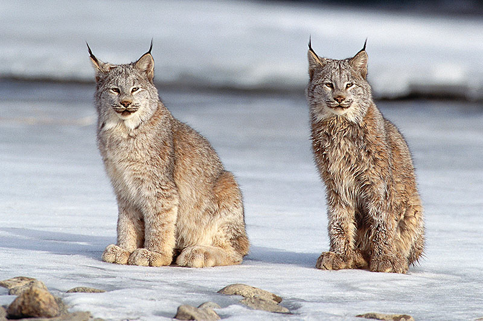

See above an image of two lynx found in BC.

# Methods

## Dataset

The dataset contains 13 variables and there are 178 rows, or entries. The variables include `countryCode` (str, which have all been filtered to CA for Canada), `stateProvince` (str, filtered for British Columbia), `higherClassification` (str, additional species information). `month` (int, month of occurrence), `locality` (str, region description), `higherGeography` (str, more broad region), `sex` (str, contains male, female, or NA), `decimalLatitude` (float), `decimalLongitude` (float), `dateIdentified` (date-time value, date of identification), `coordinateUncertaintyInMeters` (int, uncertainty value), `footprintWKT` (list of int, measurement values), and `country` (str, filtered to Canada).

## Workflow

To begin, first moment descriptive statistics were visualized. Basic `spatstat` features were used to transform to a `ppp` object, as well as visualize the spatial data on the appropriate window, which in this case, is the province of BC map. The elevation was also attached to the data, and basic elevation features were visualized on the window.  
After that we examined the intensity of lynx locations and assessed homogeneity through a quadrat test, which revealed that the distribution was not homogeneous. We then used inhomogeneous k-function and pair correlation function to investigate the correlation of lynx locations. Then we fitted several models and selected them based on AIC scores and likelihood ratio test. Furthermore, we performed a quadrat test to determine if the selected model accurately predicts the data or if there are deviations. Additionally, we explored the potential benefits of adding other covariates to our models. To assess the efficacy of our models, partial residual plots were used to identify whether our model capturing the data well or not.

## Code

```r
lc <- read.csv("../datasets/processed/lc.csv")
suppressMessages(library(spatstat))
suppressMessages(library(sf))
load("../datasets/raw/BC_Covariates.Rda")
bc_window_sf <- st_as_sf(DATA$Window)
bc_window_owin <- as.owin(bc_window_sf)
# Convert to a ppp object
lc_ppp <- ppp(x = lc$decimalLongitude, # X coordinates
              y = lc$decimalLatitude, # Y coordinates
              window = bc_window_owin, # Observation window
              )
lc_ppp <- as.ppp(lc_ppp)
# Plot the ppp object
plot(lc_ppp,
     pch = 16,
     cex = 0.5,
     cols = "#046C9A",
     main = "Marked Canada Lynx")
intensity(lc_ppp)
Q <- quadratcount(lc_ppp,
                  nx = 2,
                  ny = 4)
plot(intensity(Q, image = T),
     main = "Lynx intensity")
plot(lc_ppp, pch = 16, cex = 0.6, cols = "white", add = T)
plot(lc_ppp, pch = 16, cex = 0.5, cols = "black", add = T)
#plotting on BC map
library(raster)
dmap1 <- density.ppp(lc_ppp, sigma = bw.ppl(lc_ppp),edge=T)
r1 <- raster(dmap1)
library(leaflet)
#make sure we have right CRS, which in this case is British National Grid
bc_crs <- "+proj=aea +lat_0=45 +lon_0=-126 +lat_1=50 +lat_2=58.5 +x_0=1000000 +y_0=0 +datum=NAD83 +units=m +no_defs"
crs(r1) <- sp::CRS(bc_crs)
# create a colour palet
pal <- colorNumeric(c("#41B6C4", "red"), values(r1),
  na.color = "transparent")
#and then make map
leaflet() %>%
  addTiles() %>%
  addRasterImage(r1, colors = pal, opacity = 0.8) %>%
  addLegend(pal = pal, values = values(r1),
    title = "Canada Lynx in BC")
quadrat.test(Q)
col_pal <- colorRampPalette(c('orange', 'green'))
# Calculate nearest neighbor distances
nn_dist <- data.frame(nndist(lc_ppp))
# Add distance to nearest neighbor mark
marks(lc_ppp) <- nn_dist
# Plot point pattern with distance to nearest neighbor mark
plot(lc_ppp, main = "Seperation Distance",
     which.marks = NULL,
     cols = col_pal(nrow(nn_dist)), #The colours of the points
     pch = 16)
# Estimate the k- function
k_lc <- Kest(lc_ppp)
# visualise the results
plot (k_lc, main = "Homogeneous K-Function", lwd = 2)
# Bootstrapped CIs
# rank = 1 means the max and min
# values will be used for CI
E_lc <- envelope(lc_ppp , Kest , rank = 1, nsim = 19, fix.n = T)
# visualise the results
plot (E_lc , main = "Homogeneous K-function")
#Estimate intensity
lambda_lc <- density(lc_ppp, bw.ppl)
Kinhom_lc <- Kinhom(lc_ppp, lambda_lc)
# Estimate a strictly positive density
lambda_lc_pos <- density(lc_ppp, sigma=bw.ppl, positive=TRUE)
# Simulation envelope (with points drawn from the estimated intensity)
E_lc_inhom <- envelope(lc_ppp,
                        Kinhom,
                        simulate = expression(rpoispp(lambda_lc_pos)),
                        correction="border",
                        rank = 1,
                        nsim = 19,
                        fix.n = TRUE)
# visualise the results
plot(E_lc_inhom, xlim = c(0,320000), main = "Inhomogeneous K-function", lwd = 2)
#Simulation envelope (with points drawn from the estimated intensity)
pcf_lc_inhom <- envelope(lc_ppp,
                          pcfinhom,
                          simulate = expression(rpoispp(lambda_lc_pos)),
                          rank = 1,
                          nsim = 19)

# visualise the results
par(mfrow = c(1,2))
plot(pcf_lc_inhom, main = "Inhomogeneous g-function")
# Zoom in on range where significant deviations appear
plot(pcf_lc_inhom, xlim = c(0,20000), main = "", lwd = 2)
library(viridis)
library(viridisLite)
cols = terrain.colors(5)
# Create 5 elevation classes with equal width
elev_classes <- cut(DATA$Elevation, breaks = 5, labels = c("low", "low-medium", "medium", "high-medium", "high"))
#table(elev_classes[lc_ppp])
# Plot the elevation class image and overlay the lynx locations
# plot(elev_classes, col = cols, main = "Elevation Classes", par(bg="grey50", cex.main = 2, cex = 0.6))
# points(lc_ppp, pch = 16, cex = 0.6, col = "black")

# Create 5 forest classes with equal width
forest_classes <- cut(DATA$Forest, breaks = 5, labels = c("low", "low-medium", "medium", "high-medium", "high"))
#table(forest_classes[lc_ppp])
# plot(forest_classes, col = cols, main = "Forest Classes", par(bg="grey50", cex.main = 2, cex = 0.6))
# points(lc_ppp, pch = 16, cex = 0.6, col = "black")

# Create 5 human footprint index classes with equal width
hfi_classes <- cut(DATA$HFI, breaks = 5, labels = c("low", "low-medium", "medium", "high-medium", "high"))
#table(hfi_classes[lc_ppp])
# plot(hfi_classes, main = "Footprint Index Classes", par(bg="grey50", cex.main = 2, cex = 0.6))
# points(lc_ppp, pch = 16, cex = 0.5, col = "white")

# Create 5 dist water classes with equal width
dist_water_classes <- cut(DATA$Dist_Water, breaks = 5, labels = c("low", "low-medium", "medium", "high-medium", "high"))
#table(dist_water_classes[lc_ppp])
# plot(dist_water_classes, main = "Dist Water Classes", par(bg="grey50", cex.main = 2, cex = 0.6))
# points(lc_ppp, pch = 16, cex = 0.5, col = "white")

#plot all at once
par(mfrow = c(2,2))
par(mar=c(0,0,2,1))
#1
plot(elev_classes, col = cols, main = "Elevation Classes", par(bg="grey50", cex.main = 2, cex = 0.6))
points(lc_ppp, pch = 16, cex = 0.6, col = "black")
#2
plot(forest_classes, col = cols, main = "Forest Classes", par(bg="grey50", cex.main = 2, cex = 0.6))
points(lc_ppp, pch = 16, cex = 0.6, col = "black")
#3
plot(hfi_classes, main = "Footprint Index Classes", par(bg="grey50", cex.main = 2, cex = 0.6))
points(lc_ppp, pch = 16, cex = 0.5, col = "white")
#4
plot(dist_water_classes, main = "Dist Water Classes", par(bg="grey50", cex.main = 2, cex = 0.6))
points(lc_ppp, pch = 16, cex = 0.5, col = "white")
par(mfrow = c(1,1))
#Estimate Rho
hfi = DATA$HFI
rho_hfi = rhohat(lc_ppp, hfi)
distw = DATA$Dist_Water
rho_distw = rhohat(lc_ppp, distw)
elev = DATA$Elevation
rho_elev = rhohat(lc_ppp, elev)
forest = DATA$Forest
rho_forest = rhohat(lc_ppp, forest)

par(mfrow = c(2,2))
par(mar=c(0,0,2,1))
plot(rho_elev,
     main = "",
     xlab = "Elevation (m)",
     xlim=c(0, 3600))
plot(rho_forest,
     main = "",
     xlab = "Forest Cover (%)")
plot(rho_hfi,
     main = "",
     xlab = "Human Footprint Index")
plot(rho_distw,
     main = "",
     xlab = "Distance to Water (m)")
par(mfrow = c(1,1))
#correlation
cor.im(elev, forest, hfi, distw,  use = 'complete.obs')
# Convert to a ppp object
lc_ppp <- ppp(x = lc$decimalLongitude, # X coordinates
              y = lc$decimalLatitude, # Y coordinates
              window = bc_window_owin, # Observation window
              )
lc_ppp <- as.ppp(lc_ppp)

mu <- mean(DATA$Elevation)
stdev <- sd(DATA$Elevation)
Elevation_scaled <- eval.im((elev - mu)/stdev, DATA)
mu <- mean(DATA$Dist_Water)
stdev <- sd(DATA$Dist_Water)
Dist_Water_scaled <- eval.im((distw - mu)/stdev, DATA)
# intercept only
fit_intercept = ppm(lc_ppp ~ 1, data = DATA)
fit1 = ppm(lc_ppp ~ Elevation_scaled + I(Elevation_scaled^2) + hfi + I(hfi^2))
fit1
AIC(fit1); AIC(fit_intercept)
anova(fit_intercept, fit1, test = "LRT") #LRT
quadrat.test(fit1, nx = 2, ny = 4)
#lurking variable plot
lurking(fit1, forest, type = "raw", cumulative = F, envelope = T, xlab = "Forest Coverage (%)" )
#lurking variable plot
lurking(fit1, Dist_Water_scaled, type = "raw", cumulative = F, envelope = T, xlab = "Water Distance" )
#partial residuals
par_res_elev = parres(fit1, "Elevation_scaled")
par_res_hfi = parres(fit1, 'hfi')
par(mfrow = c(1,2))
plot(par_res_elev,
     legend = FALSE,
     lwd = 2,
     main = "",
     xlab = "Elevation Scaled")
plot(par_res_hfi,
     legend = FALSE,
     lwd = 2,
     main = "",
     xlab = "HFI")
par(mfrow = c(1,1))
fit2 = ppm(lc_ppp ~ Elevation_scaled + I(Elevation_scaled^2) + I(Elevation_scaled^3) + hfi + I(hfi^2))
fit2
AIC(fit1); AIC(fit2)
anova(fit1, fit2, test = "LRT") #LRT
#partial residuals
par_res_elev = parres(fit2, "Elevation_scaled")
par_res_hfi = parres(fit2, 'hfi')
par(mfrow = c(1,2))
plot(par_res_elev,
     legend = FALSE,
     lwd = 2,
     main = "",
     xlab = "Elevation Scaled")
plot(par_res_hfi,
     legend = FALSE,
     lwd = 2,
     main = "",
     xlab = "HFI")
par(mfrow = c(1,1))
#plotting ppm prediction
plot(fit2,
     se = FALSE,
     superimpose = FALSE,
     n = 150)
plot(lc_ppp,
     pch = 16,
     cex = 0.6,
     cols = "white",
     add = TRUE)
plot(lc_ppp,
     pch = 16,
     cex = 0.5,
     cols = "black",
     add = TRUE)
```

# Results

## First Moment Descriptives

Below we will see a plot of Canadian Lynx within BC.

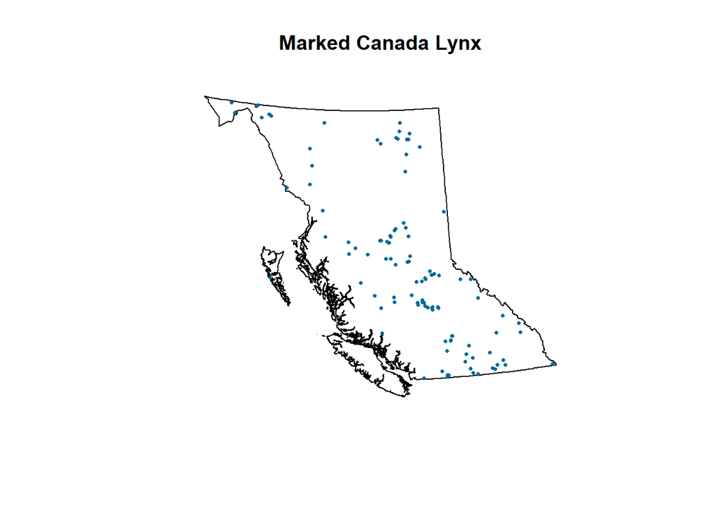

### Intensity

To determine the intensity of the Lynx across the region, we compute the value itself.

```
## [1] 1.856026e-10
```

This value means that there are 1.856026e-10 Lynx found per square meter in BC.

We can also see the intensity with observations through quadratcount.

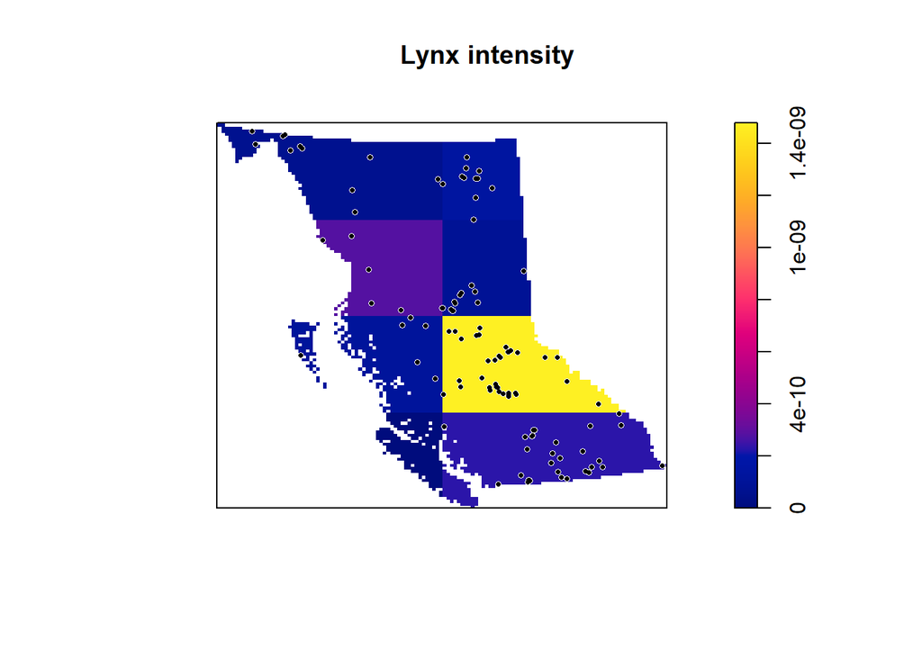

### Plot on BC Map

[interactive chart not shown]

From the plots above, it can be seen that the assumption of homogeneity is not appropriate for this dataset as the lynx tend to be clustered in certain areas of the study site, whereas others have no lynx at all.

Next, we can perform a quadrat test of homogeneity to determine if, statistically, the assumption of homogeneity is met.

```
##
##  Chi-squared test of CSR using quadrat counts
##
## data:
## X2 = 54.379, df = 7, p-value = 3.958e-09
## alternative hypothesis: two.sided
##
## Quadrats: 8 tiles (irregular windows)
```

The small p-value suggests that there is a significant deviation from homogeneity. So, the assumption of homogeneity is not met.

### Nearest Neighbour Distances

Now we can compute nearest neighbor distances.

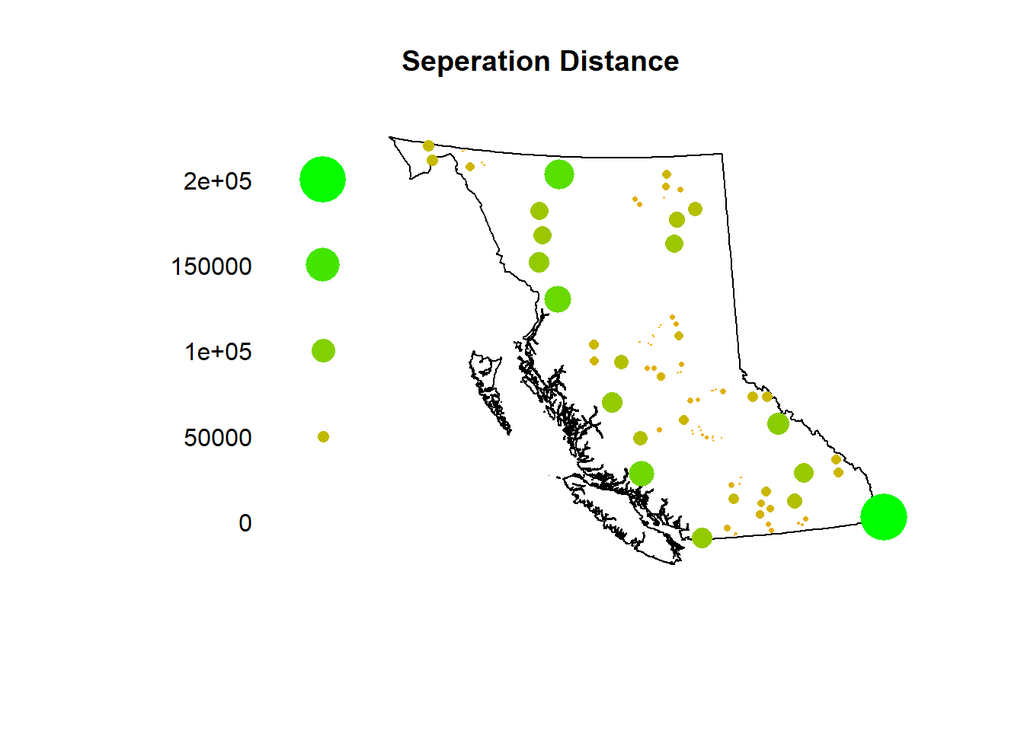

## Second Moment Descriptives

Following this, second moment descriptive statistics were visualized.

### K-Function

The K-Function will be the first visualization of this section.

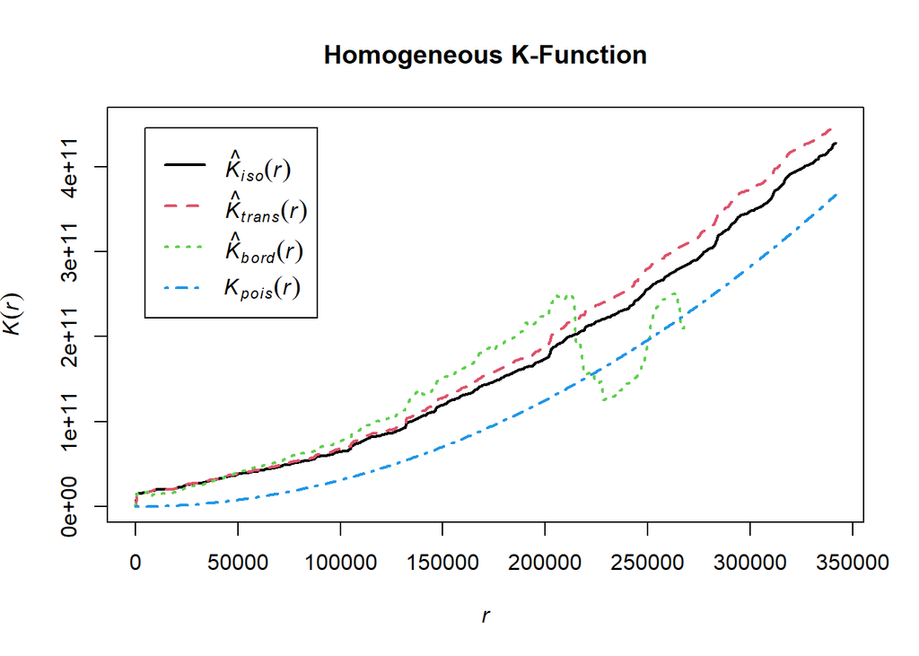

Here we can see that theoretical k-function $k_{pois}(r)$ deviates from other k-function corrections indicates clustering but these estimates assume homogeneity.

```
## Generating 19 simulations of CSR with fixed number of points  ...
## 1, 2, 3, 4, 5, 6, 7, 8, 9, 10, 11, 12, 13, 14, 15, 16, 17, 18,  19.
##
## Done.
```

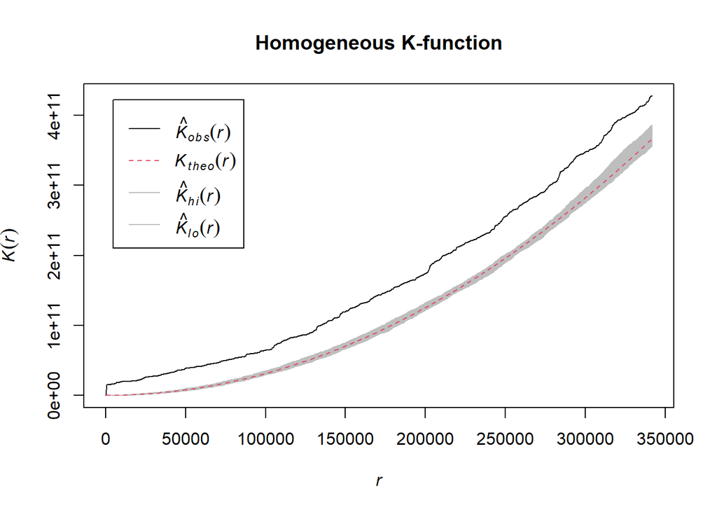

From this, we have evidence that suggests significant clustering, but these estimates assume homogeneity.

Now we can relax the homogeneity assumption.

```
## Generating 19 simulations by evaluating expression  ...
## 1, 2, 3, 4, 5, 6, 7, 8, 9, 10, 11, 12, 13, 14, 15, 16, 17, 18,  19.
##
## Done.
```

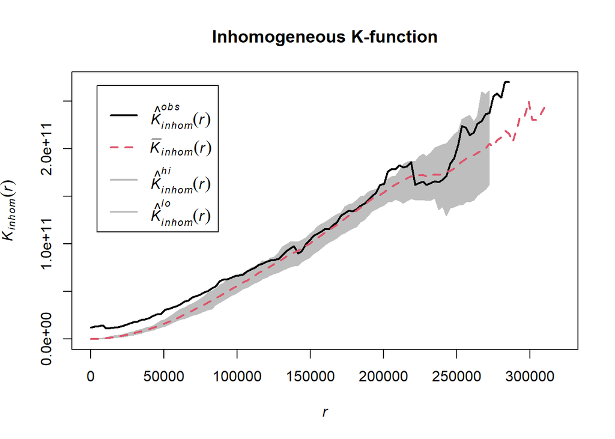

When correcting for inhomogeneity, the clustering is not as strong homogeneous k-function. Clustering appears to exist in and around 0 to 125000 units and 275000 to 300000 units.

### Pair Correlation Function

The pair correlation function can be used next.

```
## Generating 19 simulations by evaluating expression  ...
## 1, 2, 3, 4, 5, 6, 7, 8, 9, 10, 11, 12, 13, 14, 15, 16, 17, 18,  19.
##
## Done.
```

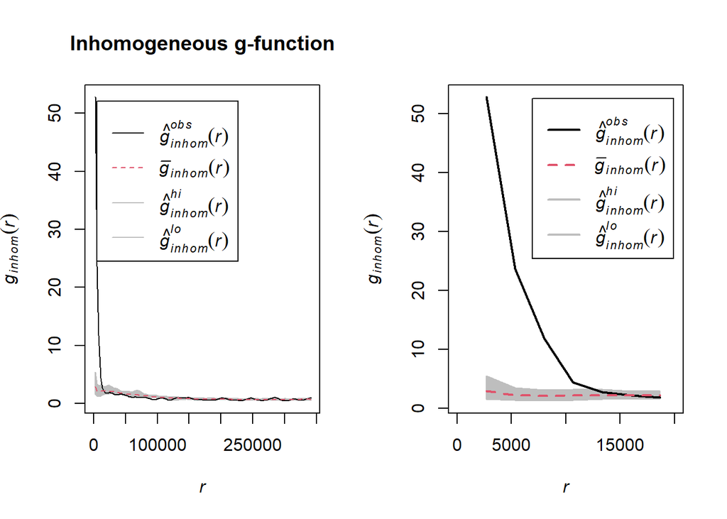

There appear to be more lynx than expected by random chance between 0 - 13500 as $g(r) > 1$. Beyond that, the locations of lynx appear not to exhibit any significant correlations.

## Relationships with Covariates

We are usually interested in determining whether the intensity depends on a covariate(s). One simple approach to check for a relationship between inhomogeneous $\lambda(u)$ and a spatial covariate $Z(u)$ is via quadrat counting. We can create five elevation classes with equal width below.

Now we can look at the distribution of the elevation classes in the window, the province of BC.

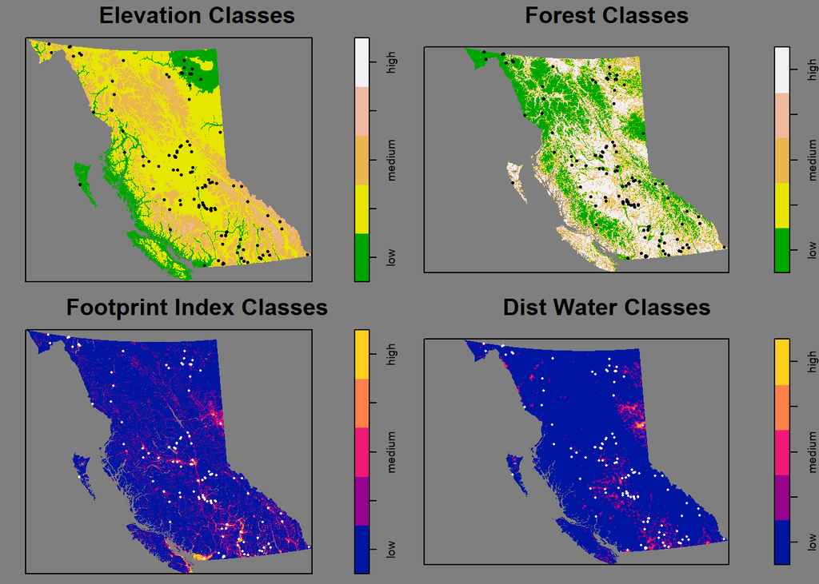

More formally, in testing for relationships with covariates we are assuming that $λ$ is a function of $Z$, such that
$$\lambda(u)=\rho(Z(u))$$

A non-parametric estimate of $\rho$ can be obtained via kernel estimation, available via the rhohat() function.

We can see the plot of Rho with elevation.

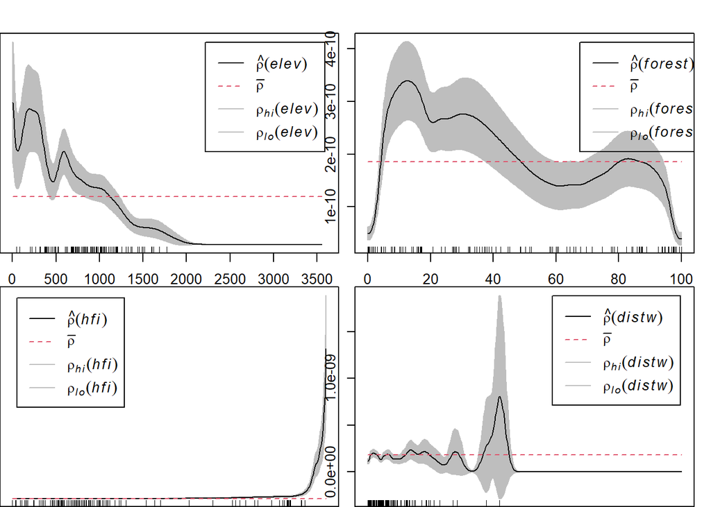

There is a non-linear relationship between elevation and lynx intensity. Majority of the lynx are at low elevations than would be expected by chance, fewer lynx at intermediate elevations and no lynx at high elevations.

```
##             ..1         ..2         ..3         ..4
## ..1  1.00000000 -0.26225376 -0.26625626 -0.03493453
## ..2 -0.26225376  1.00000000  0.06618592  0.04818598
## ..3 -0.26625626  0.06618592  1.00000000  0.13246899
## ..4 -0.03493453  0.04818598  0.13246899  1.00000000
```

The correlation coefficients are relatively weak. We can proceed without too much worry.

### Model Fitting

```
## Nonstationary Poisson process
## Fitted to point pattern dataset 'lc_ppp'
##
## Log intensity:  ~Elevation_scaled + I(Elevation_scaled^2) + hfi + I(hfi^2)
##
## Fitted trend coefficients:
##           (Intercept)      Elevation_scaled I(Elevation_scaled^2)
##           -23.5142168            -0.5496413            -0.1806727
##                   hfi              I(hfi^2)
##             7.9345208            -5.1926304
##
##                          Estimate       S.E.     CI95.lo     CI95.hi Ztest
## (Intercept)           -23.5142168 0.17827617 -23.8636317 -23.1648020   ***
## Elevation_scaled       -0.5496413 0.13384529  -0.8119732  -0.2873093   ***
## I(Elevation_scaled^2)  -0.1806727 0.08343033  -0.3441932  -0.0171523     *
## hfi                     7.9345208 1.15645659   5.6679075  10.2011340   ***
## I(hfi^2)               -5.1926304 1.33813978  -7.8153361  -2.5699246   ***
##                              Zval
## (Intercept)           -131.897701
## Elevation_scaled        -4.106542
## I(Elevation_scaled^2)   -2.165552
## hfi                      6.861062
## I(hfi^2)                -3.880484
## Problem:
##  Values of the covariate 'hfi' were NA or undefined at 0.44% (3 out of 689) of
## the quadrature points
##
## *** Fitting algorithm for 'glm' did not converge ***
```

In the fit1 model we can see that the coefficients are significant. We can also check the AIC score and likelihood ratio test:

```
## [1] 7965.547
```

```
## [1] 8241.409
```

[output not shown]

So based on AIC score and likelihood ratio test fit1 model is better.

```
##
##  Chi-squared test of fitted Poisson model 'fit1' using quadrat counts
##
## data:  data from fit1
## X2 = 56.478, df = 3, p-value = 6.641e-12
## alternative hypothesis: two.sided
##
## Quadrats: 8 tiles (irregular windows)
```

The small p value from the quadrat test tells us that the data deviate significantly from the model’s predictions.

Let’s check whether adding other covariates going to improve the model fit or not.

```
## Generating 39 simulated patterns ...1, 2, 3, 4, 5, 6, 7, 8, 9, 10, 11, 12, 13, 14, 15, 16, 17, 18, 19, 20, 21, 22, 23, 24, 25, 26, 27, 28, 29, 30, 31, 32, 33, 34, 35, 36, 37, 38,  39.
## Processing.. 1, 2, 3, 4, 5, 6, 7, 8, 9, 10, 11, 12, 13, 14, 15, 16, 17, 18, 19, 20, 21, 22, 23, 24, 25, 26, 27, 28, 29, 30, 31, 32, 33, 34, 35, 36, 37, 38,  39.
## Done.
```

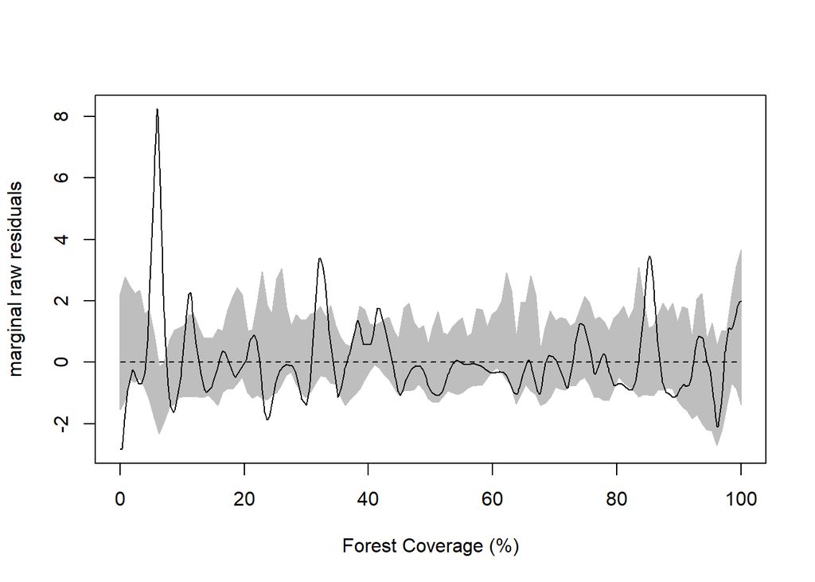

It appears that the forest coverage variable may not be significant in the model, hence we could investigate the impact of water distance instead.

```
## Generating 39 simulated patterns ...1, 2, 3, 4, 5, 6, 7, 8, 9, 10, 11, 12, 13, 14, 15, 16, 17, 18, 19, 20, 21, 22, 23, 24, 25, 26, 27, 28, 29, 30, 31, 32, 33, 34, 35, 36, 37, 38,  39.
## Processing.. 1, 2, 3, 4, 5, 6, 7, 8, 9, 10, 11, 12, 13, 14, 15, 16, 17, 18, 19, 20, 21, 22, 23, 24, 25, 26, 27, 28, 29, 30, 31, 32, 33, 34, 35, 36, 37, 38,  39.
## Done.
```

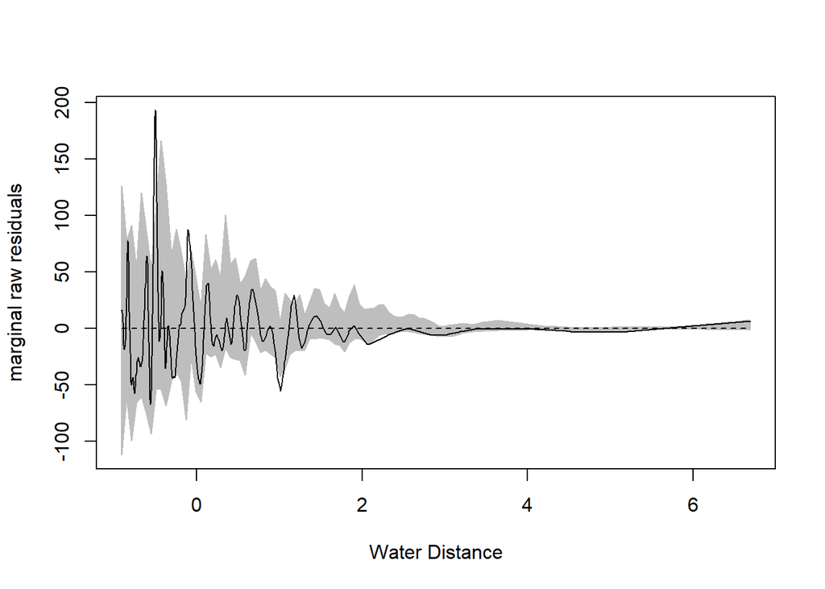

So, water distance is unrelated to trends in the residuals. We can diagnose our model further by partial residual plots to check how we can improve.

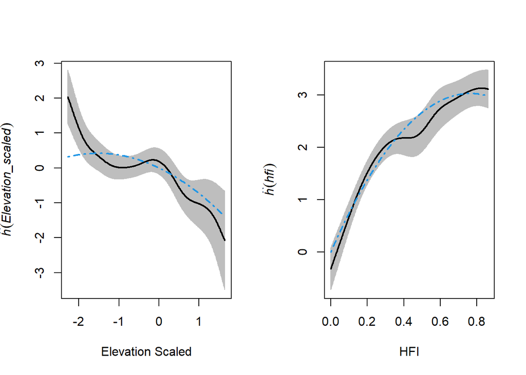

From these figures we can see that the quadratic term of HFI is capturing the patterns in our data particularly well but we can improve the elevation by adding higher order plynomials.

```
## Nonstationary Poisson process
## Fitted to point pattern dataset 'lc_ppp'
##
## Log intensity:  ~Elevation_scaled + I(Elevation_scaled^2) +
## I(Elevation_scaled^3) + hfi + I(hfi^2)
##
## Fitted trend coefficients:
##           (Intercept)      Elevation_scaled I(Elevation_scaled^2)
##           -23.3153723            -0.3313493            -0.5725852
## I(Elevation_scaled^3)                   hfi              I(hfi^2)
##            -0.2390356             7.8927824            -5.1130689
##
##                          Estimate       S.E.     CI95.lo       CI95.hi Ztest
## (Intercept)           -23.3153723 0.19003181 -23.6878278 -22.942916820   ***
## Elevation_scaled       -0.3313493 0.17000882  -0.6645604   0.001861899
## I(Elevation_scaled^2)  -0.5725852 0.20504110  -0.9744583  -0.170711992    **
## I(Elevation_scaled^3)  -0.2390356 0.09724718  -0.4296365  -0.048434603     *
## hfi                     7.8927824 1.14898528   5.6408127  10.144752191   ***
## I(hfi^2)               -5.1130689 1.33437971  -7.7284051  -2.497732762   ***
##                              Zval
## (Intercept)           -122.691945
## Elevation_scaled        -1.949012
## I(Elevation_scaled^2)   -2.792538
## I(Elevation_scaled^3)   -2.458021
## hfi                      6.869350
## I(hfi^2)                -3.831795
## Problem:
##  Values of the covariate 'hfi' were NA or undefined at 0.44% (3 out of 689) of
## the quadrature points
##
## *** Fitting algorithm for 'glm' did not converge ***
```

These values indicate that:

AIC values for squared model and cubed model, respectively:

```
## [1] 7965.547
```

```
## [1] 7960.116
```

Likelihood ratio test for squared and cubed models:

```
## Analysis of Deviance Table
##
## Model 1: ~Elevation_scaled + I(Elevation_scaled^2) + hfi + I(hfi^2)   Poisson
## Model 2: ~Elevation_scaled + I(Elevation_scaled^2) + I(Elevation_scaled^3) + hfi + I(hfi^2)   Poisson
##   Npar Df Deviance Pr(>Chi)
## 1    5
## 2    6  1   7.4317 0.006409 **
## ---
## Signif. codes:  0 '***' 0.001 '**' 0.01 '*' 0.05 '.' 0.1 ' ' 1
```

The small p-value indicates that the additional complexity supported by data.

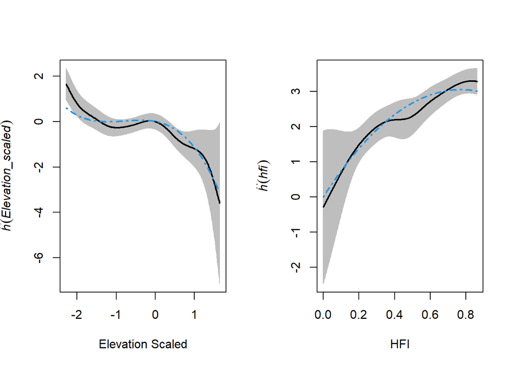

In addition, the inclusion of extra elevation polynomial term slightly enhances the accuracy of the model predictions.

Since the model is already performing well, we are not considering to add any additional complexity to it.

Plotting `ppm` predictions:

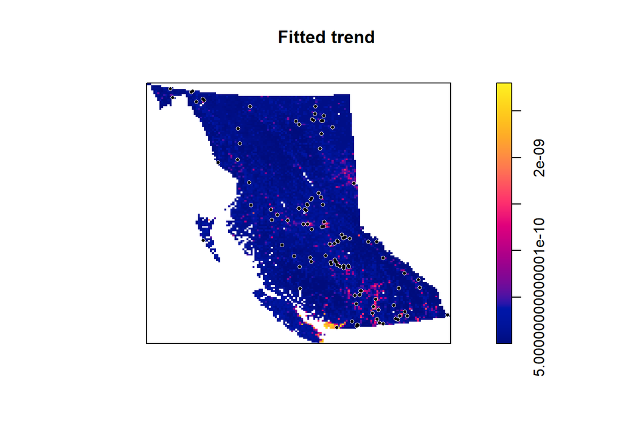

There are still locations where the model seems to not be a particularly good match to the data, but it is actually performing reasonably well considering that we are predicting the locations of lynx in BC based on only elevation and human footprint index, and have no information on all of the many other factors that might influence lynx locations.

# Discussion

Overall, we can make a few inferences as mentioned above regarding the lynx species in BC, but given that the data had fewer than 200 observation points, despite the lynx population in BC being estimated at much larger amounts, this needs to be taken into account. In the future, it would be beneficial to complete an analysis with a larger dataset to either confirm or reassess our results.

# References

GBIF.org (01 April 2023) GBIF Occurrence Download https://doi.org/10.15468/dl.zeymyk